# Default

Bar Chart

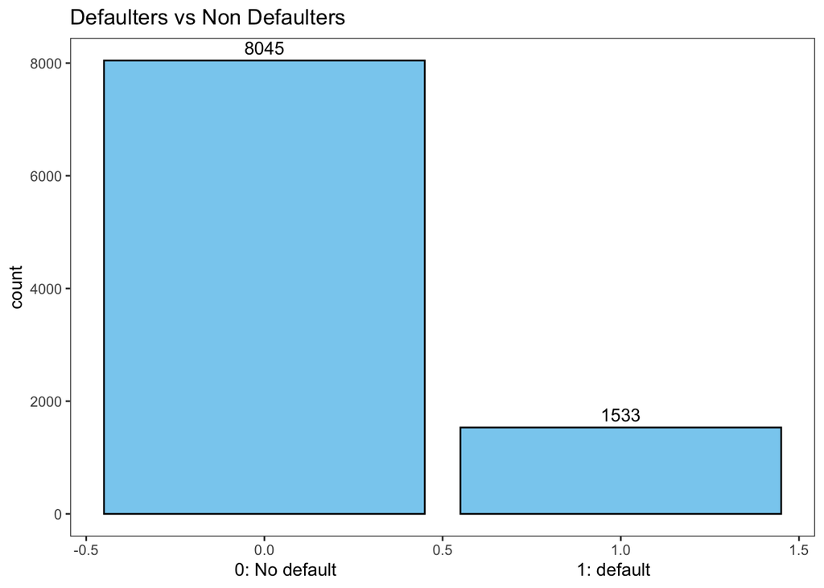

```r
ggplot(loan_data,aes(x=not.fully.paid), color = '#89CFF0') +
  geom_bar(fill = '#89CFF0', color = 'black') +
  xlab('0: No default                                                1: default') +
  ggtitle('Defaulters vs Non Defaulters') +
  geom_text(stat = "count", aes(label = after_stat(count)), vjust = -0.5)+
  theme_test()
```

Naturally due to the consequences of not paying back loans most people will pay back their loans. This is great news for the bank but unfortunate news for anyone trying to build predictive models. Defaulters make up about 16% of those who take out debts in the sample. This is an imbalanced data set that could result in inaccurate prediction rates. This will be taken to account and up sampling will be implemented into the recipe to make sure the models are trained on a higher proportion of defaulters.

Pie Chart

```r
#spliting the credit scores into 4 ranges

#600-650
total1 <- sum(loan_data$not.fully.paid[loan_data$fico > 600 & loan_data$fico < 650])
count1 <- sum(loan_data$fico > 600 & loan_data$fico < 650)
low = total1/count1

#650 - 700
total2 <- sum(loan_data$not.fully.paid[loan_data$fico > 650 & loan_data$fico < 700])
count2 <- sum(loan_data$fico > 650 & loan_data$fico < 700)
fair = total2/count2

#700 - 750
total3 <- sum(loan_data$not.fully.paid[loan_data$fico > 700 & loan_data$fico < 750])
count3 <- sum(loan_data$fico > 700 & loan_data$fico < 750)
better = total3/count3

#750-800
total4 <- sum(loan_data$not.fully.paid[loan_data$fico > 750 & loan_data$fico < 800])
count4 <- sum(loan_data$fico > 750 ) #& loan_data$fico < 800)
best = total4/count4
```

```r
Rating <- c('600-650','650-700','700-750','750-800')
Default_rate <- c(low,fair,better,best)
RDR <- data.frame(Rating,Default_rate)
```

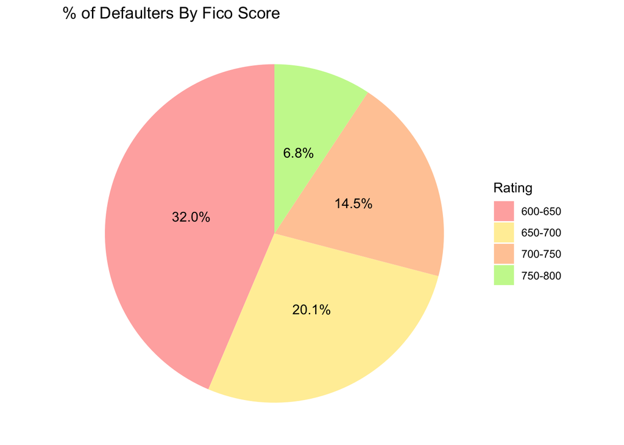

```r
pie_plot <- ggplot(RDR, aes(x = "", y = Default_rate, fill = Rating)) +
  geom_bar(stat = "identity", width = 1) +
  coord_polar(theta = "y") +
  theme_void() +
  labs(title = "% of Defaulters By Fico Score")+
  scale_fill_manual(values=c('#FFB1AF','#FFEEA5','#FFCBA5','#C8F69B'))+
  geom_text(aes(label = scales::percent(Default_rate)), position = position_stack(vjust = 0.5))+
  theme(legend.position = "right")

print(pie_plot)
```

Loan Purpose Profile

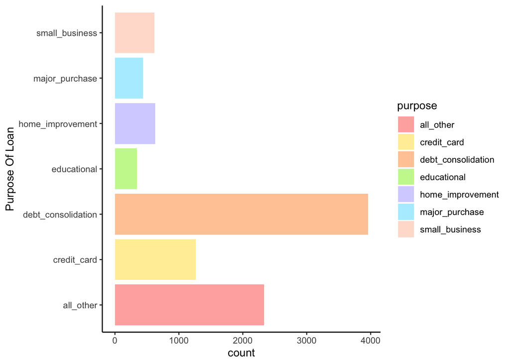

```r
ggplot(data = loan_data,aes(x = purpose, fill = purpose)) +
  geom_bar() +
  coord_flip() +
  scale_fill_manual(values=c('#FFB1AF','#FFEEA5','#FFCBA5','#C8F69B','#D6D4FF','#B3EEFF','#FFDFD3')) +
  xlab('Purpose Of Loan') +
  theme_classic()
```

A majority of the loans are debt consolidation which is taking out one new loan to replace all your old loans. Not necessarily a different loan but just an aggregate. After that you have other loans and then other credit card debt.

## Data Splitting and Cross-Validation

Splitting the data

```r
loan_data$not.fully.paid <- as.factor(loan_data$not.fully.paid)

loan_split <- initial_split(loan_data, prop = 0.75, strata = not.fully.paid)

loan_train <- training(loan_split)

loan_test <- testing(loan_split)
```

Data is split into a testing and training split to ensure that we have a test set that our model has not seen and a training set to which the model is trained on. This allows us to emulate real data points to see how the model would perform in a real world setting.

Creating k folds for cross validation

```r
loan_folds <- vfold_cv(loan_train, v = 5)
loan_folds
```

```
## #  5-fold cross-validation
## # A tibble: 5 × 2
##   splits              id
##   <list>              <chr>
## 1 <split [5745/1437]> Fold1
## 2 <split [5745/1437]> Fold2
## 3 <split [5746/1436]> Fold3
## 4 <split [5746/1436]> Fold4
## 5 <split [5746/1436]> Fold5
```

## Recipe

Before data can be used to train a model it must go through pre-processing. The tidyverse package utilizes a function called recipe for this purpose.

Cleaned data set so there is no missing values. No need to impute any values.

Nominal predictors such as purpose of loan was transformed into dummy variables.

Normalized all numeric variables excluding binary indicators, this allows for stability of the model and makes sure its consistent among predictors.

```r
loan_recipe <- recipe(not.fully.paid ~ int.rate + installment + log.annual.inc + dti + fico +
                 days.with.cr.line + revol.bal + revol.util + inq.last.6mths +
                 delinq.2yrs + pub.rec + purpose,  data = loan_train) %>%
  step_dummy(all_nominal_predictors()) %>%
  step_upsample(not.fully.paid, over_ratio = 0.6, skip = TRUE) %>%
  step_normalize( int.rate, installment, log.annual.inc, dti, fico,
                 days.with.cr.line, revol.bal, revol.util, inq.last.6mths,
                 delinq.2yrs, pub.rec)

prep(loan_recipe) %>%
  bake(new_data = loan_train) %>%
  head() %>%
  kable() %>%
  kable_styling(full_width = F) %>%
  scroll_box(width = '100%', height = '200px')
```

| int.rate | installment | log.annual.inc | dti | fico | days.with.cr.line | revol.bal | revol.util | inq.last.6mths | delinq.2yrs | pub.rec | not.fully.paid | purpose_credit_card | purpose_debt_consolidation | purpose_educational | purpose_home_improvement | purpose_major_purchase | purpose_small_business |
| --- | --- | --- | --- | --- | --- | --- | --- | --- | --- | --- | --- | --- | --- | --- | --- | --- | --- |
| -0.6876078 | -0.4490514 | 0.2615111 | 0.2105699 | 0.0090130 | -0.7066296 | 0.3484059 | 0.9662538 | -0.7336616 | -0.3109773 | -0.2582597 | 0 | 1 | 0 | 0 | 0 | 0 | 0 |
| 0.3853176 | 0.2129022 | -0.8806173 | -0.1758053 | -0.6601697 | 0.0787167 | -0.3386802 | -0.7800444 | -0.3088685 | -0.3109773 | -0.2582597 | 0 | 0 | 1 | 0 | 0 | 0 | 0 |
| -0.9239515 | -0.7636035 | 0.6938703 | -0.6885512 | 0.1428496 | -0.7308109 | 0.3494098 | 0.8466444 | -0.3088685 | -0.3109773 | -0.2582597 | 0 | 0 | 1 | 0 | 0 | 0 | 0 |
| 0.6441703 | -1.0473115 | 0.6121989 | 0.3093425 | -1.0616793 | -0.1806490 | -0.3106372 | -0.3050240 | -0.7336616 | 1.5037463 | -0.2582597 | 0 | 1 | 0 | 0 | 0 | 0 | 0 |
| -1.7492787 | -0.9412671 | 1.5876524 | 0.6013026 | 0.5443592 | 0.6465992 | 0.7405049 | 0.0879786 | -0.7336616 | -0.3109773 | -0.2582597 | 0 | 1 | 0 | 0 | 0 | 0 | 0 |
| -0.1248847 | -1.1370744 | -1.1544424 | -0.4125690 | 0.0090130 | -0.7186951 | -0.2903295 | -0.8688972 | -0.3088685 | -0.3109773 | -0.2582597 | 0 | 0 | 1 | 0 | 0 | 0 | 0 |

## K-Nearest Neighbors

```r
knn_model <- nearest_neighbor(neighbors = tune()) %>%
  set_engine('kknn') %>%
  set_mode('classification')

knn_wflow <- workflow() %>%
  add_model(knn_model) %>%
  add_recipe(loan_recipe)
```

K-nearest Neighbors works based off a hyper parameter called neighbors. Neighbors is the size of the surrounding observations around the Data point for which a prediction is to be generated. In a classification setting, the predicted outcome will be what has the highest observed probability of occurring within this K size group of neighbors.

Since K is a hyper parameter, it can be tuned to return the best metric desired on the folds. Since the goal of the project is to supply banks with a model that has a strong ability to distinguish between defaulters and non defaulters, the highest possible roc_auc is the goal.

```r
neighbors_grid <- grid_regular(neighbors(range = c(1, 20)), levels = 20)
neighbors_grid
```

```
## # A tibble: 20 × 1
##    neighbors
##        <int>
##  1         1
##  2         2
##  3         3
##  4         4
##  5         5
##  6         6
##  7         7
##  8         8
##  9         9
## 10        10
## 11        11
## 12        12
## 13        13
## 14        14
## 15        15
## 16        16
## 17        17
## 18        18
## 19        19
## 20        20
```

Here we will fit models ranging from K = 1 to K = 20.

```r
tune_knn <- tune_grid(
  object = knn_wflow,
  resamples = loan_folds,
  grid = neighbors_grid,
  control = control_grid(verbose = TRUE)
)
```

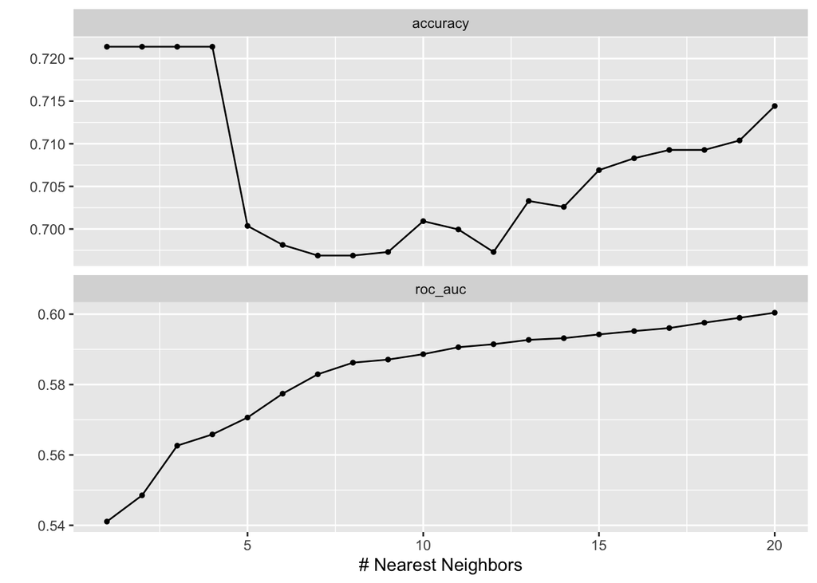

```r
#write_rds(tune_knn, file = "tune_knn.rds")

tune_knn <- read_rds("tune_knn.rds")



autoplot(tune_knn)
```

The roc_auc is a metric of the model, the closer it is to 1 the better that the model is able to distinguish between a defaulter and not a defaulter. Therefore we will tune to highest roc_auc level.

```r
collect_metrics(tune_knn)
```

```
## # A tibble: 40 × 7
##    neighbors .metric  .estimator  mean     n std_err .config
##        <int> <chr>    <chr>      <dbl> <int>   <dbl> <chr>
##  1         1 accuracy binary     0.721     5 0.00562 Preprocessor1_Model01
##  2         1 roc_auc  binary     0.541     5 0.00491 Preprocessor1_Model01
##  3         2 accuracy binary     0.721     5 0.00562 Preprocessor1_Model02
##  4         2 roc_auc  binary     0.549     5 0.00561 Preprocessor1_Model02
##  5         3 accuracy binary     0.721     5 0.00562 Preprocessor1_Model03
##  6         3 roc_auc  binary     0.563     5 0.00679 Preprocessor1_Model03
##  7         4 accuracy binary     0.721     5 0.00562 Preprocessor1_Model04
##  8         4 roc_auc  binary     0.566     5 0.00851 Preprocessor1_Model04
##  9         5 accuracy binary     0.700     5 0.00614 Preprocessor1_Model05
## 10         5 roc_auc  binary     0.571     5 0.00693 Preprocessor1_Model05
## # ℹ 30 more rows
```

Here is the results of the hyper parameter tuning.

```r
knn_metrics <- collect_metrics(tune_knn)

best_knn <- select_by_one_std_err(tune_knn,
                          metric = "roc_auc",
                          neighbors)
best_knn
```

```
## # A tibble: 1 × 9
##   neighbors .metric .estimator  mean     n std_err .config          .best .bound
##       <int> <chr>   <chr>      <dbl> <int>   <dbl> <chr>            <dbl>  <dbl>
## 1         9 roc_auc binary     0.587     5 0.00893 Preprocessor1_M… 0.600  0.587
```

Out of all the KNN models chosen, the model with the best combination of tuning values is chosen. The best K is 9 with an roc_auc of 0.587

## Elastic Net

Workflow

```r
elastic_loan_model <- logistic_reg(mixture = tune(),  penalty = tune()) %>%
  set_mode("classification") %>%
  set_engine("glmnet")

elastic_loan_wflow <- workflow() %>%
  add_model(elastic_loan_model) %>%
  add_recipe(loan_recipe)
```

```r
en_grid <- grid_regular(penalty(range = c(0, 1),
                        trans = identity_trans()),
                        mixture(range = c(0, 1)),
                        levels = 10)
```

In an elastic net model, the first parameter tuned is penalty. Penalty shrinks the coefficients of the Betas when calculating the sum of squares residuals.

The second parameter tuned is mixture, which allows for the fitting of both ridge and lasso regression models. 0 being a ridge model and 1 being a lasso model. Lasso shrinks based of the absolute values of the Beta coefficients while Ridge regression shrinks based off of the beta coefficients squared.

```r
tune_EN_loan <- tune_grid(
  elastic_loan_wflow,
  resamples = loan_folds,
  grid = en_grid,
  control = control_grid(verbose = TRUE)
)

tune_EN_loan
```

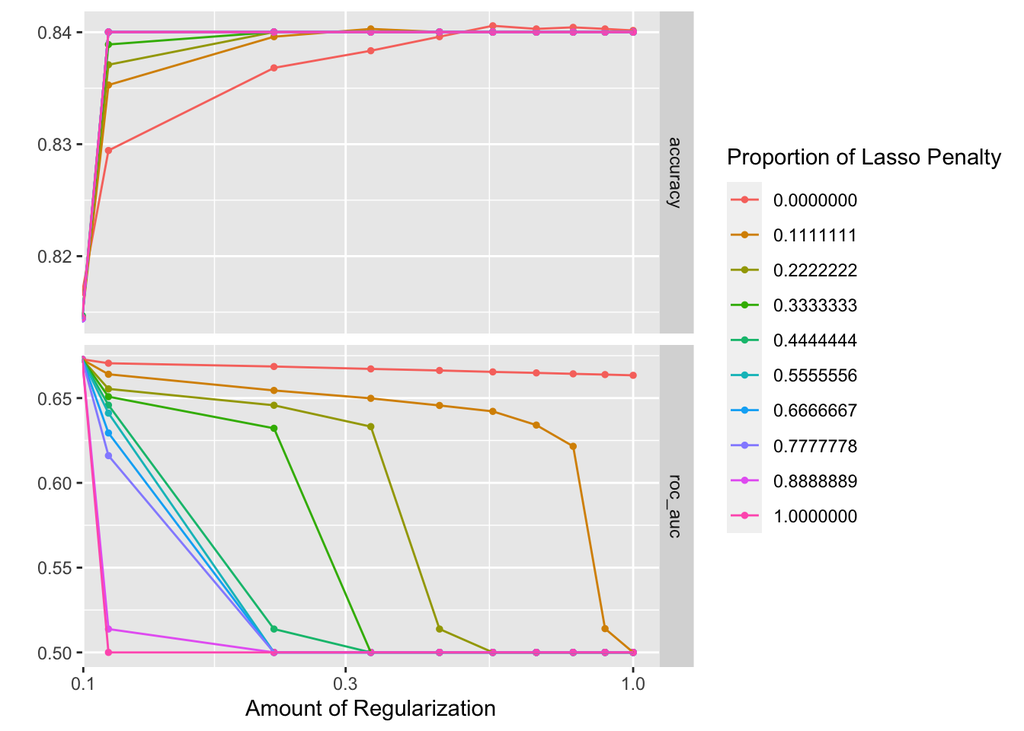

```r
#write_rds(tune_EN_loan, file = "tune_EN.rds")

tune_EN_loan <- read_rds("tune_EN.rds")



autoplot(tune_EN_loan)
```

```r
collect_metrics(tune_EN_loan)
```

```
## # A tibble: 200 × 8
##    penalty mixture .metric  .estimator  mean     n  std_err .config
##      <dbl>   <dbl> <chr>    <chr>      <dbl> <int>    <dbl> <chr>
##  1   0           0 accuracy binary     0.817     5 0.00281  Preprocessor1_Model…
##  2   0           0 roc_auc  binary     0.673     5 0.0111   Preprocessor1_Model…
##  3   0.111       0 accuracy binary     0.829     5 0.00165  Preprocessor1_Model…
##  4   0.111       0 roc_auc  binary     0.671     5 0.0122   Preprocessor1_Model…
##  5   0.222       0 accuracy binary     0.837     5 0.000924 Preprocessor1_Model…
##  6   0.222       0 roc_auc  binary     0.669     5 0.0124   Preprocessor1_Model…
##  7   0.333       0 accuracy binary     0.838     5 0.000908 Preprocessor1_Model…
##  8   0.333       0 roc_auc  binary     0.667     5 0.0124   Preprocessor1_Model…
##  9   0.444       0 accuracy binary     0.840     5 0.00133  Preprocessor1_Model…
## 10   0.444       0 roc_auc  binary     0.666     5 0.0124   Preprocessor1_Model…
## # ℹ 190 more rows
```

By displaying the model’s metrics we can see how it has performed across each level of penalty and mixture.

```r
en_metrics_loan <- collect_metrics(tune_EN_loan)




best_en <- select_by_one_std_err(tune_EN_loan,
                          metric = "roc_auc",
                          penalty,
                          mixture
                         )
best_en
```

```
## # A tibble: 1 × 10
##   penalty mixture .metric .estimator  mean     n std_err .config    .best .bound
##     <dbl>   <dbl> <chr>   <chr>      <dbl> <int>   <dbl> <chr>      <dbl>  <dbl>
## 1       0       0 roc_auc binary     0.673     5  0.0111 Preproces… 0.673  0.662
```